# 2021 Fasting Cancer Project

Charlie Whittaker

1/19/2021 - revised 6/13/2024

# Set options and working directory

# Load libraries

```r
library(Seurat)
library(tidyverse)
library(cowplot)
library(umap)
library(Matrix)
library(readxl)
library(openxlsx)
library(ggrepel)
library(ggpubr)
library(sctransform)
library(knitr)
library(kableExtra)
library(DESeq2)
```

## Import marker sets

```r
gene.lists <- read_xlsx("Munoz_Yilmaz_CellCycle_signatures.xlsx")
gene.lists.names <- colnames(gene.lists)
GOI.lists <- c()
for (i in gene.lists.names) {
  tmpList <- gene.lists %>% dplyr::select(all_of(i))
  tmpList <- tmpList[!is.na(tmpList)]
  GOI.lists[[i]] <- tmpList
}
```

# Load the Cell Ranger Matrix Data and create the base Seurat object

the initial processing was done with r 3.6.1 with Seurat 3.2.0 - results can vary slightly with different versions of R and seurat

#```{r} #al.dat <- Read10X(“200218Yil_data/al/filtered_feature_bc_matrix/”) #f.dat <- Read10X(“200218Yil_data/f/filtered_feature_bc_matrix/”) #rf.dat <- Read10X(“200218Yil_data/rf/filtered_feature_bc_matrix/”) #rf.rapa.dat <- Read10X(“200218Yil_data/rf.rapa/filtered_feature_bc_matrix/”)

#al <- CreateSeuratObject(counts = al.dat, project = “al”, min.cells = 3, min.features = 200) #f <- CreateSeuratObject(counts = f.dat, project = “f”, min.cells = 3, min.features = 200) #rf <- CreateSeuratObject(counts = rf.dat, project = “rf”, min.cells = 3, min.features = 200) #rf.rapa <- CreateSeuratObject(counts = rf.rapa.dat, project = “rf.rapa”, min.cells = 3, min.features = 200)

#al[[“percent.mt”]] <- PercentageFeatureSet(al, pattern = “^mt-”) #f[[“percent.mt”]] <- PercentageFeatureSet(f, pattern = “^mt-”) #rf[[“percent.mt”]] <- PercentageFeatureSet(rf, pattern = “^mt-”) #rf.rapa[[“percent.mt”]] <- PercentageFeatureSet(rf.rapa, pattern = “^mt-”)

#VlnPlot(al, features = c(“nFeature_RNA”, “nCount_RNA”, “percent.mt”), ncol = 3) #VlnPlot(f, features = c(“nFeature_RNA”, “nCount_RNA”, “percent.mt”), ncol = 3) #VlnPlot(rf, features = c(“nFeature_RNA”, “nCount_RNA”, “percent.mt”), ncol = 3) #VlnPlot(al, features = c(“nFeature_RNA”, “nCount_RNA”, “percent.mt”), ncol = 3) #```

## Merge samples to single Seurat Object

#```{r} #merged_Seu <- merge(al, c(f,rf,rf.rapa), project = “Diet”)

#merged_Seu <- NormalizeData(merged_Seu, normalization.method = “LogNormalize”, scale.factor = 10000) #merged_Seu <- FindVariableFeatures(merged_Seu, selection.method = “vst”, nfeatures = 2000) #merged_Seu <- ScaleData(merged_Seu) #merged_Seu <- RunPCA(merged_Seu, features = VariableFeatures(object = merged_Seu)) #merged_Seu <- RunUMAP(merged_Seu, reduction=“pca”,dims=1:30) #merged_Seu <- RunTSNE(merged_Seu, reduction=“pca”,dims=1:30) #merged_Seu <- FindNeighbors(merged_Seu, dims = 1:30, verbose = FALSE) #merged_Seu <- FindClusters(merged_Seu, verbose = FALSE)

#DimPlot(merged_Seu,reduction=“umap”,group.by=“orig.ident”,label=TRUE,repel=FALSE)

#FeaturePlot(merged_Seu,reduction=“umap”,features=“mt-Cytb”,min.cutoff=0,max.cutoff=4,cols=c(“grey”,“red”)) #FeaturePlot(merged_Seu,reduction=“umap”,features=“percent.mt”,cols=c(“grey”,“red”)) #FeaturePlot(merged_Seu,reduction=“umap”,features=“nFeature_RNA”,cols=c(“grey”,“red”)) #```

## Save/Load seurat object

#`{r} #save(merged_Seu, file="merged.Robj") #load("merged.Robj") #`

## Dataset Integration

#```{r} #di <- SplitObject(merged_Seu, split.by = “orig.ident”)

#for (i in 1:length(di)) { # di[[i]] <- NormalizeData(di[[i]], verbose = FALSE) # di[[i]] <- FindVariableFeatures(di[[i]], selection.method = “vst”, nfeatures = 2000, # verbose = FALSE) #}

#dat.anchors <- FindIntegrationAnchors(object.list=di,dims=1:30) #integrated <- IntegrateData(anchorset=dat.anchors,dim=1:30)

#DefaultAssay(integrated)<-“integrated” #integrated <- ScaleData(integrated) #integrated <- RunPCA(integrated,npcs=30) #integrated <- RunUMAP(integrated,reduction=“pca”,dims=1:30) #integrated <- RunTSNE(integrated,reduction=“pca”,dims=1:30) #integrated <- FindNeighbors(integrated, dims = 1:30, verbose = FALSE) #integrated <- FindClusters(integrated, verbose = FALSE) #```

# Load pre-processed integrated data for analysis

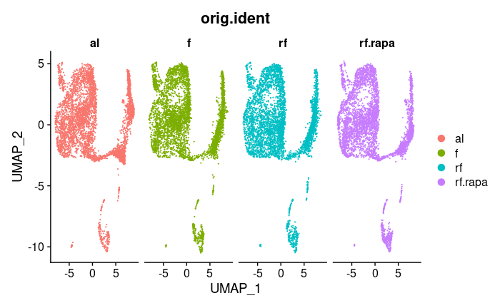

```r
load("integrated_091120.Robj")
DefaultAssay(integrated)<-"integrated"
DimPlot(integrated,reduction="umap",split.by="orig.ident",group.by="orig.ident")
```

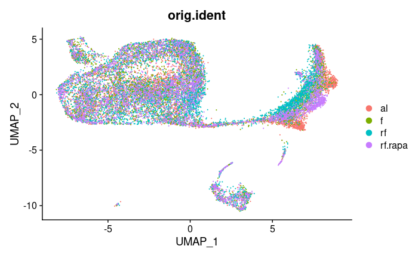

```r
DimPlot(integrated,reduction="umap",group.by="orig.ident")
```

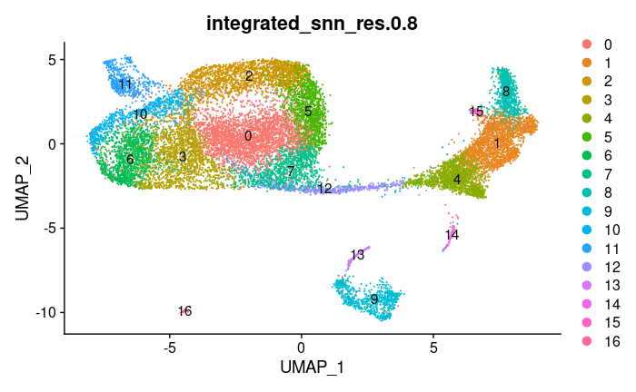

```r
DimPlot(integrated,reduction="umap",group.by="integrated_snn_res.0.8", label=TRUE)
```

## Add cluster/treatment metadata columns and plot labeled UMAP

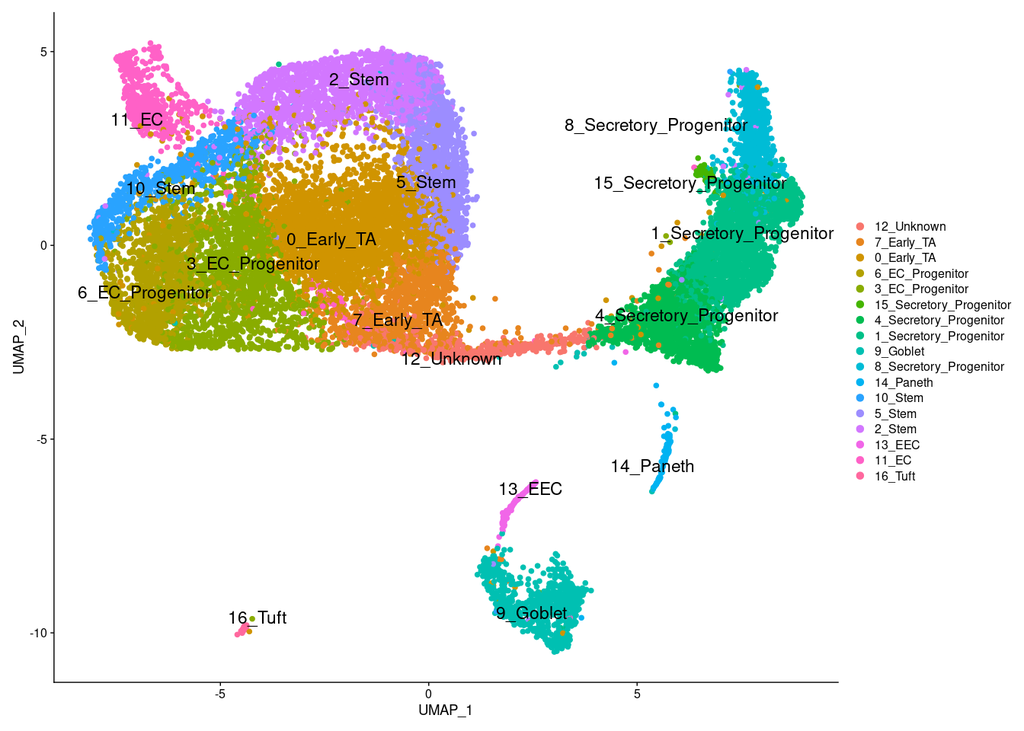

```r
integrated@meta.data$treat_clust <- paste0(integrated@meta.data$orig.ident,integrated@meta.data$integrated_snn_res.0.8)
integrated@meta.data$clust_treat <- paste0(integrated@meta.data$integrated_snn_res.0.8,integrated@meta.data$orig.ident)
integrated@meta.data$celltype <- integrated@meta.data$integrated_snn_res.0.8
Idents(object = integrated) <- integrated$celltype

integrated <- RenameIdents(object = integrated,  '16' = '16_Tuft')
integrated <- RenameIdents(object = integrated,  '11' = '11_EC')
integrated <- RenameIdents(object = integrated,  '13' = '13_EEC')
integrated <- RenameIdents(object = integrated,  '2' = '2_Stem')
integrated <- RenameIdents(object = integrated,  '5' = '5_Stem')
integrated <- RenameIdents(object = integrated,  '10' = '10_Stem')
integrated <- RenameIdents(object = integrated,  '14' = '14_Paneth')
integrated <- RenameIdents(object = integrated,  '8' = '8_Secretory_Progenitor')
integrated <- RenameIdents(object = integrated,  '9' = '9_Goblet')
integrated <- RenameIdents(object = integrated,  '1' = '1_Secretory_Progenitor')
integrated <- RenameIdents(object = integrated,  '4' = '4_Secretory_Progenitor')
integrated <- RenameIdents(object = integrated,  '15' = '15_Secretory_Progenitor')
integrated <- RenameIdents(object = integrated,  '3' = '3_EC_Progenitor')
integrated <- RenameIdents(object = integrated,  '6' = '6_EC_Progenitor')
integrated <- RenameIdents(object = integrated,  '0' = '0_Early_TA')
integrated <- RenameIdents(object = integrated,  '7' = '7_Early_TA')
integrated <- RenameIdents(object = integrated,  '12' = '12_Unknown')
DimPlot(integrated,reduction="umap", label=TRUE, repel=TRUE, pt.size=2, label.size=6)
```

# LGR5 Vln plot

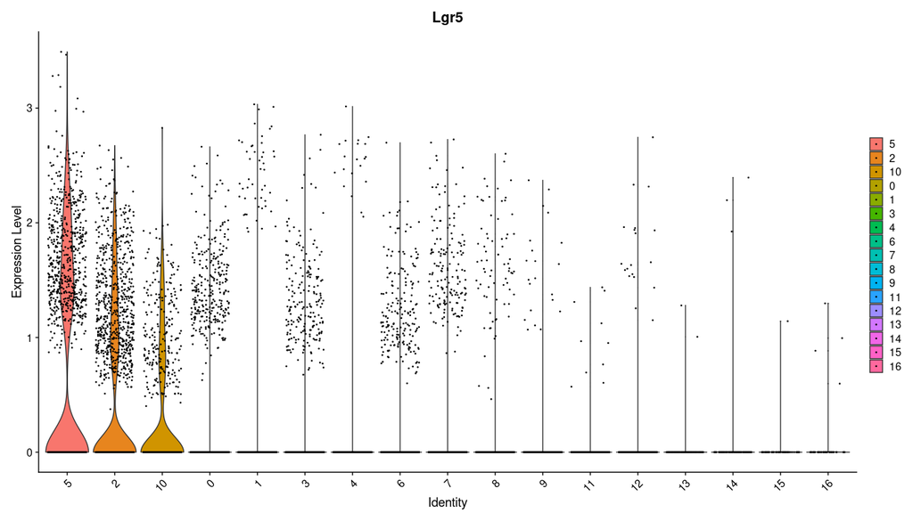

```r
DefaultAssay(integrated)<-"RNA"
Idents(object = integrated) <- integrated$integrated_snn_res.0.8
plotOrder <- c("5","2","10","0","1","3","4","6","7","8","9","11","12","13","14","15","16")
Idents(integrated) <- factor(Idents(integrated), levels= plotOrder)
VlnPlot(integrated, idents = , features = c("Lgr5"), pt.size = 0.3, slot="data")
```

# Table of cell counts in each integrated data cluster and sample

```r
p.integrated <- table(integrated@meta.data$integrated_snn_res.0.8,integrated@meta.data$orig.ident)
round(prop.table(p.integrated,2),3)
```

```
        al     f    rf rf.rapa
  0  0.169 0.191 0.135   0.178
  1  0.096 0.101 0.135   0.119
  2  0.082 0.116 0.104   0.102
  3  0.099 0.091 0.098   0.101
  4  0.125 0.078 0.082   0.061
  5  0.076 0.080 0.084   0.072
  6  0.076 0.074 0.065   0.077
  7  0.056 0.040 0.096   0.055
  8  0.078 0.053 0.034   0.037
  9  0.028 0.046 0.043   0.060
  10 0.034 0.032 0.044   0.055
  11 0.026 0.056 0.033   0.029
  12 0.039 0.028 0.024   0.032
  13 0.005 0.006 0.009   0.009
  14 0.005 0.005 0.006   0.007
  15 0.002 0.002 0.005   0.005
  16 0.004 0.002 0.004   0.001
```

# Biton heatmap

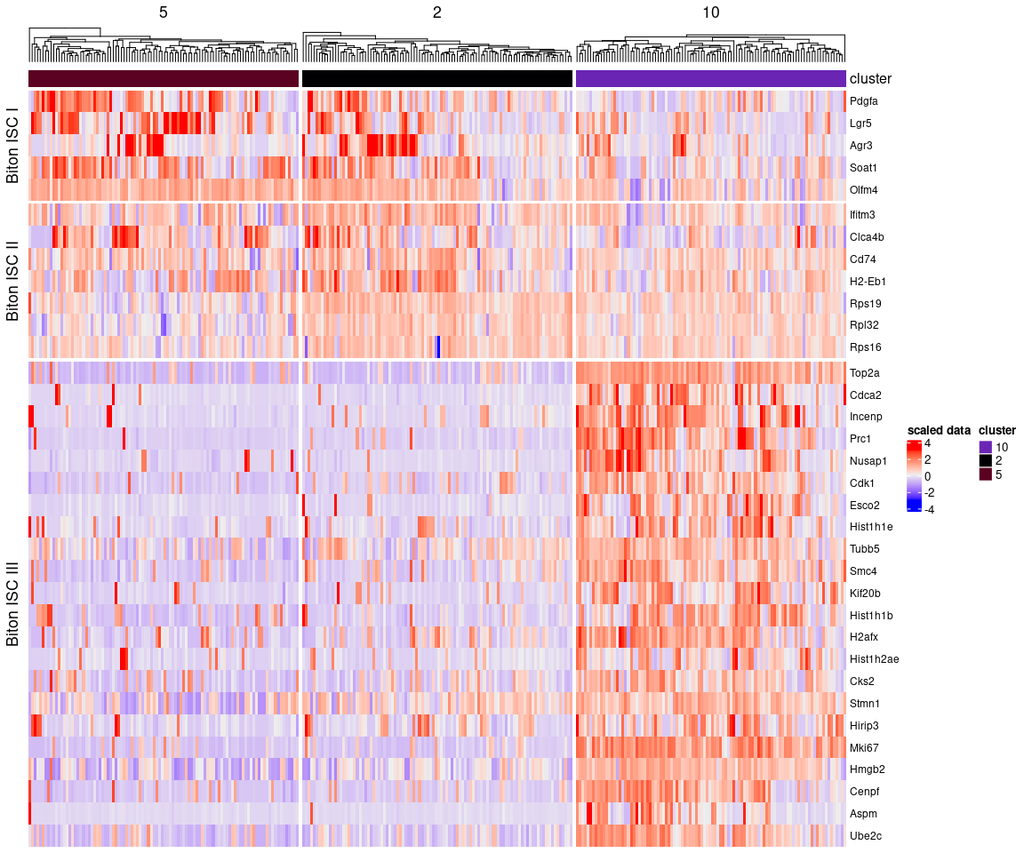

```r
DefaultAssay(integrated)<- "integrated"
Idents(object = integrated) <- integrated$integrated_snn_res.0.8
dd <- subset(integrated, idents = c("2", "5", "10"), downsample=100)

topvst <- head(VariableFeatures(dd), 500)
mat <- as.matrix(dd@assays$integrated@scale.data) #as.matrix(subset_dd@assays$integrated@scale.data)
mat <- mat[topvst,]

genes <- c(GOI.lists$Biton_S1_ISC.I, GOI.lists$Biton_S1_ISC.II, GOI.lists$Biton_S1_ISC.III)
labels <- c(rep('Biton ISC I', length(GOI.lists$Biton_S1_ISC.I)),
            rep('Biton ISC II', length(GOI.lists$Biton_S1_ISC.II)),
            rep('Biton ISC III', length(GOI.lists$Biton_S1_ISC.III)))

idxs <- which(genes %in% rownames(mat))
genes <- genes[idxs]
labels <- labels[idxs]
mat <- mat[genes,]

ht <- Heatmap(mat, column_names_side = 'top', row_names_gp = gpar(fontsize = 9), column_names_gp = gpar(fontsize = 12),
              column_title = '', name = 'scaled data', column_labels = rep('', ncol(mat)),
              column_split = factor(as.character(dd$integrated_snn_res.0.8), levels = c('5', '2', '10')),
              row_split = labels, row_order = genes, #column_order = sort(colnames(mat)),
              cluster_column_slices = FALSE,
              top_annotation = HeatmapAnnotation(cluster = as.character(dd$integrated_snn_res.0.8)))

draw(ht)
```

# GSEA dot plots

```r
data <- as.data.frame(read_excel('cluster_2_5_10stem_gsea.xlsx', sheet = 'Sheet2'))
data
```

| NAME | Comparison | NES | FDR q-val |
| --- | --- | --- | --- |
| BITON_S1_ISC.I | f5_v_al5.noNA.NES | 1.3215407 | 0.2682069200 |
| BITON_S1_ISC.II | f5_v_al5.noNA.NES | 2.0391748 | 0.0000000000 |
| BITON_S1_ISC.III | f5_v_al5.noNA.NES | -1.1991149 | 0.3889467000 |
| BITON_S1_ISC.I | rf5_v_al5.noNA.NES | 1.7629898 | 0.0019750001 |
| BITON_S1_ISC.II | rf5_v_al5.noNA.NES | 2.2566988 | 0.0000000000 |
| BITON_S1_ISC.III | rf5_v_al5.noNA.NES | 0.8156711 | 0.9565237000 |
| BITON_S1_ISC.I | rf.rapa5_v_al5.noNA.NES | 0.9629948 | 0.9024616000 |
| BITON_S1_ISC.II | rf.rapa5_v_al5.noNA.NES | 2.0106223 | 0.0000000000 |
| BITON_S1_ISC.III | rf.rapa5_v_al5.noNA.NES | 0.7934456 | 0.9918505500 |
| BITON_S1_ISC.I | f2_v_al2.noNA.NES | 1.3257033 | 0.2230794400 |

[output cut: 17 more lines]

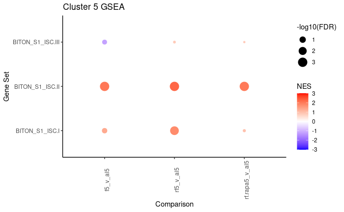

```r
data$FDR <- data$`FDR q-val` + 0.001
data$Comparison <- gsub('\\.noNA\\.NES','',data$Comparison)

comparisons <- c('f5_v_al5', 'rf5_v_al5', 'rf.rapa5_v_al5')
sub_data <- data[which(data$Comparison %in% comparisons),]
cl5 <- ggplot(data=sub_data, aes(y=NAME, x=factor(Comparison, levels = comparisons), size=-log10(FDR), color=NES)) +
  geom_point() +
  scale_color_gradient2(midpoint=0, low="blue", mid="white",
                        high="red", space ="Lab", limits=c(-3,3))+
  scale_size_continuous(range=c(1,6))+
  ggtitle('Cluster 5 GSEA') + theme_classic() +
  theme(legend.position="right", axis.text.x = element_text(angle = 90)) + ylab('Gene Set') + xlab('Comparison')
cl5
```

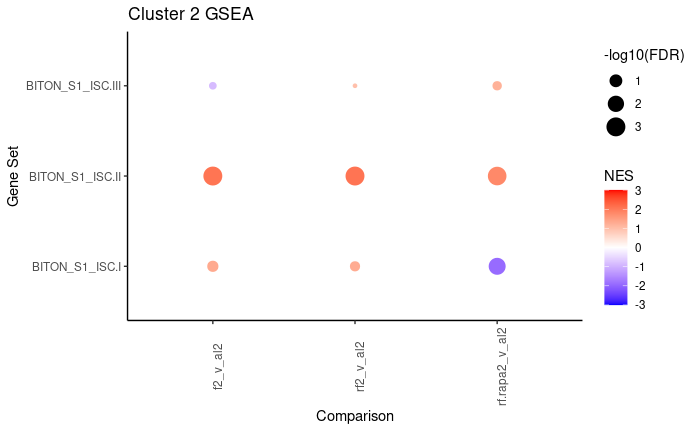

```r
comparisons <- c('f2_v_al2', 'rf2_v_al2', 'rf.rapa2_v_al2')
sub_data <- data[which(data$Comparison %in% comparisons),]
cl2 <- ggplot(data=sub_data, aes(y=NAME, x=factor(Comparison, levels = comparisons), size=-log10(FDR), color=NES)) +
  geom_point() +
  scale_color_gradient2(midpoint=0, low="blue", mid="white",
                        high="red", space ="Lab", limits=c(-3,3))+
  scale_size_continuous(range=c(1,6))+
  ggtitle('Cluster 2 GSEA') + theme_classic() +
  theme(legend.position="right", axis.text.x = element_text(angle = 90)) + ylab('Gene Set') + xlab('Comparison')
cl2
```

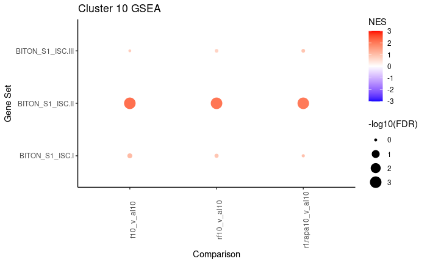

```r
comparisons <- c('f10_v_al10', 'rf10_v_al10', 'rf.rapa10_v_al10')
sub_data <- data[which(data$Comparison %in% comparisons),]
cl10 <- ggplot(data=sub_data, aes(y=NAME, x=factor(Comparison, levels = comparisons), size=-log10(FDR), color=NES)) +
  geom_point() +
  scale_color_gradient2(midpoint=0, low="blue", mid="white",
                        high="red", space ="Lab", limits=c(-3,3))+
  scale_size_continuous(range=c(1,6))+
  ggtitle('Cluster 10 GSEA') + theme_classic() +
  theme(legend.position="right", axis.text.x = element_text(angle = 90)) + ylab('Gene Set') + xlab('Comparison')
cl10
```

# Feature Plots

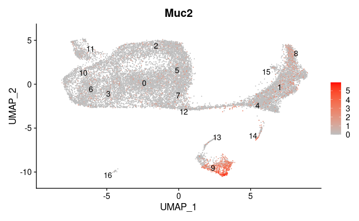

```r
DefaultAssay(integrated)<-"RNA"
fp.Muc2 <- FeaturePlot(integrated,reduction="umap",features="Muc2",cols=c("grey","red"), slot = "data",label=TRUE, repel=TRUE,label.size=4)
fp.Muc2
```

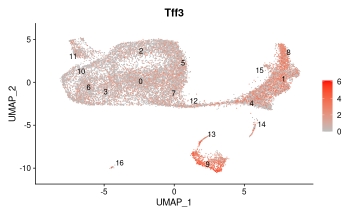

```r
fp.Tff3 <- FeaturePlot(integrated,reduction="umap",features="Tff3",cols=c("grey","red"), slot = "data",label=TRUE, repel=TRUE,label.size=4)
fp.Tff3
```

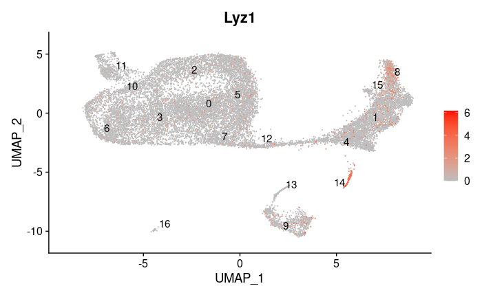

```r
fp.Lyz1 <- FeaturePlot(integrated,reduction="umap",features="Lyz1",cols=c("grey","red"), slot = "data",label=TRUE, repel=TRUE,label.size=4)
fp.Lyz1
```

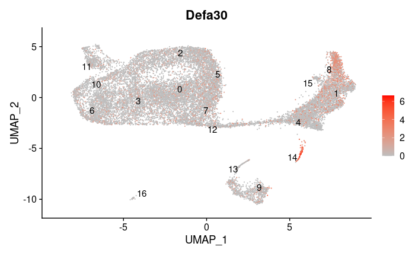

```r
fp.Defa30 <- FeaturePlot(integrated,reduction="umap",features="Defa30",cols=c("grey","red"), slot = "data",label=TRUE, repel=TRUE,label.size=4)
fp.Defa30
```

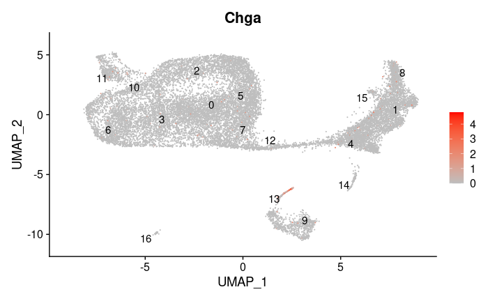

```r
fp.Chga <- FeaturePlot(integrated,reduction="umap",features="Chga",cols=c("grey","red"), slot = "data",label=TRUE, repel=TRUE,label.size=4)
fp.Chga
```

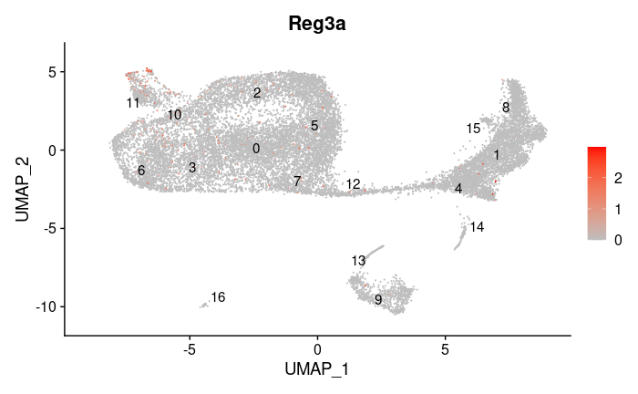

```r
fp.Reg3a <- FeaturePlot(integrated,reduction="umap",features="Reg3a",cols=c("grey","red"), slot = "data",label=TRUE, repel=TRUE,label.size=4)
fp.Reg3a
```

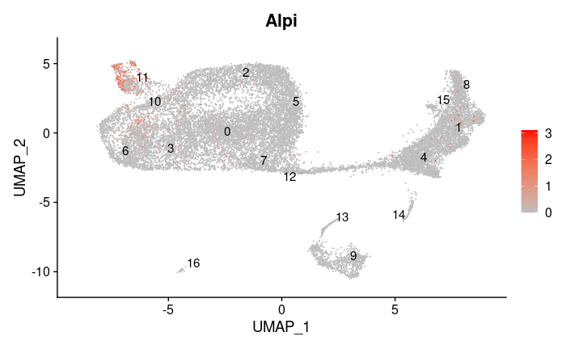

```r
fp.Alpi <- FeaturePlot(integrated,reduction="umap",features="Alpi",cols=c("grey","red"), slot = "data",label=TRUE, repel=TRUE,label.size=4)
fp.Alpi
```

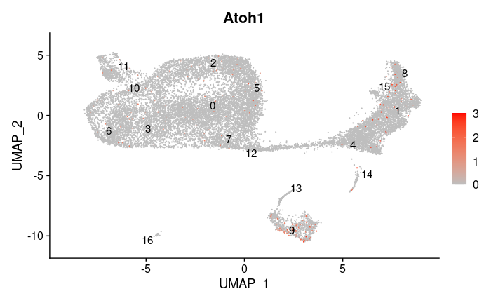

```r
fp.Atoh1 <- FeaturePlot(integrated,reduction="umap",features="Atoh1",cols=c("grey","red"), slot = "data",label=TRUE, repel=TRUE,label.size=4)
fp.Atoh1
```

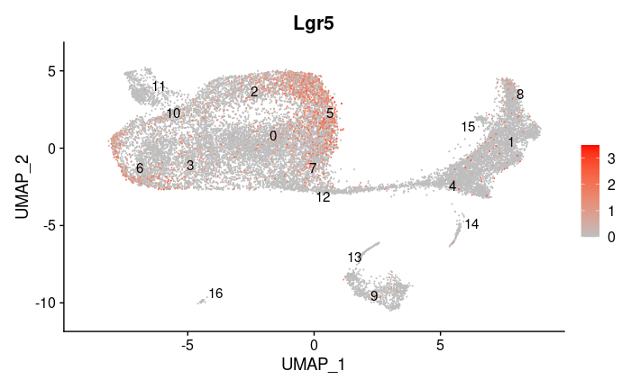

```r
fp.Lgr5 <- FeaturePlot(integrated,reduction="umap",features="Lgr5",cols=c("grey","red"), slot = "data",label=TRUE, repel=TRUE,label.size=4)
fp.Lgr5
```

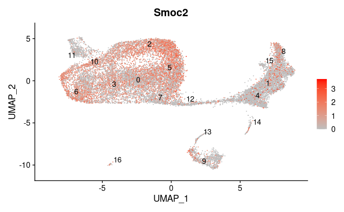

```r
fp.Smoc2 <- FeaturePlot(integrated,reduction="umap",features="Smoc2",cols=c("grey","red"), slot = "data",label=TRUE, repel=TRUE,label.size=4)
fp.Smoc2
```

# cell cycle data

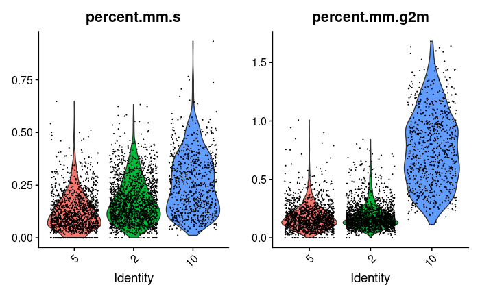

```r
DefaultAssay(integrated)<-"RNA"
gene.names <- rownames(integrated@assays$RNA@data)
Idents(object = integrated) <- integrated$seurat_clusters
stem.subset <- subset(integrated, idents = c("2","5","10"))
levels(stem.subset) <- c("5","2","10")
s.InData <- intersect(gene.names,GOI.lists$mm.s)
g2m.InData <- intersect(gene.names,GOI.lists$mm.g2m)
stem.subset[["percent.mm.s"]] <- PercentageFeatureSet(stem.subset, features = s.InData)
stem.subset[["percent.mm.g2m"]] <- PercentageFeatureSet(stem.subset, features = g2m.InData)
mm.s <- VlnPlot(stem.subset, features="percent.mm.s",pt.size = 0.1,slot = "data")
#mm.s
mm.g2m <- VlnPlot(stem.subset, features="percent.mm.g2m",pt.size = 0.1,slot = "data")
#mm.g2m

cellcycleFigure <- ggarrange(mm.s,mm.g2m, legend = FALSE, ncol=2, nrow=1)
cellcycleFigure
```

## Proportion Analysis of cell cycle data

```r
integrated[["percent.mm.s"]] <- PercentageFeatureSet(integrated, features = s.InData)
integrated[["percent.mm.g2m"]] <- PercentageFeatureSet(integrated, features = g2m.InData)

mm.g2m.Flag <- if_else(integrated@meta.data$percent.mm.g2m >= 0.3, "Yes", "No")
integrated@meta.data$mm.g2m.Flag <- mm.g2m.Flag

p <- table(integrated$clust_treat,integrated$mm.g2m.Flag)
p.g2m.summary <- round(prop.table(p,2),3)
p.g2m.summary
```

```
               No   Yes
  0al       0.075 0.009
  0f        0.079 0.006
  0rf       0.044 0.023
  0rf.rapa  0.062 0.023
  10al      0.002 0.018
  10f       0.001 0.015
  10rf      0.001 0.023
  10rf.rapa 0.001 0.028
  11al      0.012 0.001
  11f       0.023 0.002
  11rf      0.012 0.003
  11rf.rapa 0.012 0.001
  12al      0.017 0.003
  12f       0.011 0.001
  12rf      0.009 0.003
  12rf.rapa 0.012 0.004
  13al      0.002 0.000
  13f       0.002 0.001
  13rf      0.003 0.002
  13rf.rapa 0.003 0.002
  14al      0.001 0.001
  14f       0.001 0.001
  14rf      0.001 0.002
  14rf.rapa 0.002 0.002
  15al      0.000 0.001
  15f       0.000 0.001
  15rf      0.000 0.003
  15rf.rapa 0.000 0.003
  16al      0.002 0.000
  16f       0.001 0.000
  16rf      0.002 0.000
  16rf.rapa 0.000 0.000
  1al       0.008 0.046
  1f        0.014 0.036
  1rf       0.007 0.066
  1rf.rapa  0.010 0.053
  2al       0.037 0.004
  2f        0.049 0.003
  2rf       0.041 0.009
```

[output cut: 14 more lines]

```
  6f        0.001 0.037
  6rf       0.000 0.036
  6rf.rapa  0.001 0.041
  7al       0.025 0.003
  7f        0.016 0.001
  7rf       0.037 0.009
  7rf.rapa  0.021 0.005
  8al       0.005 0.039
  8f        0.004 0.022
  8rf       0.000 0.018
  8rf.rapa  0.002 0.018
  9al       0.010 0.004
  9f        0.016 0.006
  9rf       0.013 0.009
  9rf.rapa  0.018 0.011
```

```r
mm.s.Flag <- if_else(integrated@meta.data$percent.mm.s >= 0.2, "Yes", "No")
integrated@meta.data$mm.s.Flag <- mm.s.Flag

p <- table(integrated$clust_treat,integrated$mm.s.Flag)
p.s.summary <- round(prop.table(p,1),3)
p.s.summary
```

```
               No   Yes
  0al       0.840 0.160
  0f        0.792 0.208
  0rf       0.594 0.406
  0rf.rapa  0.689 0.311
  10al      0.337 0.663
  10f       0.345 0.655
  10rf      0.435 0.565
  10rf.rapa 0.463 0.537
  11al      0.992 0.008
  11f       0.988 0.013
  11rf      0.966 0.034
  11rf.rapa 0.977 0.023
  12al      0.936 0.064
  12f       0.934 0.066
  12rf      0.944 0.056
  12rf.rapa 0.896 0.104
  13al      0.783 0.217
  13f       0.917 0.083
  13rf      0.805 0.195
  13rf.rapa 0.692 0.308
  14al      0.913 0.087
  14f       0.800 0.200
  14rf      0.741 0.259
  14rf.rapa 0.833 0.167
  15al      0.300 0.700
  15f       0.429 0.571
  15rf      0.190 0.810
  15rf.rapa 0.476 0.524
  16al      0.941 0.059
  16f       1.000 0.000
  16rf      0.941 0.059
  16rf.rapa 0.750 0.250
  1al       0.471 0.529
  1f        0.513 0.487
  1rf       0.408 0.592
  1rf.rapa  0.529 0.471
  2al       0.737 0.263
  2f        0.740 0.260
  2rf       0.542 0.458
```

[output cut: 14 more lines]

```
  6f        0.952 0.048
  6rf       0.909 0.091
  6rf.rapa  0.893 0.107
  7al       0.872 0.128
  7f        0.847 0.153
  7rf       0.729 0.271
  7rf.rapa  0.771 0.229
  8al       0.425 0.575
  8f        0.474 0.526
  8rf       0.329 0.671
  8rf.rapa  0.359 0.641
  9al       0.806 0.194
  9f        0.869 0.131
  9rf       0.807 0.193
  9rf.rapa  0.822 0.178
```

# escape ssGSEA - run ssGSEA to quantify expression of the BitonI gene set clusters

This code is no longer working due to R and package updates but resulting data is stored in the seurat object

```r
# egs <- GeneSet(GOI.lists$Biton_S1_ISC.I, setName="BitonI")
# ES <- enrichIt(obj = integrated, gene.sets=egs, groups = 1000, cores = 4)
# integrated@meta.data$BitonI_ssGSEA <- ES$BitonI
#
# egs <- GeneSet(GOI.lists$Biton_S1_ISC.II, setName="BitonII")
# ES <- enrichIt(obj = integrated, gene.sets = egs, groups = 1000, cores = 4)
# integrated@meta.data$BitonII_ssGSEA <- ES$BitonII
#
# egs <- GeneSet(GOI.lists$Biton_S1_ISC.III, setName="BitonIII")
# ES <- enrichIt(obj = integrated, gene.sets = egs, groups = 1000, cores = 4)
# integrated@meta.data$BitonIII_ssGSEA <- ES$BitonIII
```

# Additional Figures

## Biton I in cluster 5

```r
Idents(object = integrated) <- integrated$seurat_clusters
clust5.subset <- subset(integrated, idents = c("5"))
Idents(object = clust5.subset) <- clust5.subset$treat_clust
plot.order <- c("al5","f5","rf5","rf.rapa5")
Idents(object = clust5.subset) <- factor(Idents(object = clust5.subset), levels = plot.order)
vln.BitonI.ssGSEA <- VlnPlot(clust5.subset, features="BitonI_ssGSEA",slot = "data",pt.size = 0.1) +
  stat_summary(fun = median, geom='point', size = 15, colour = "black", shape = 95)
vln.BitonI.ssGSEA
```

[output not shown]

## Biton II in cluster 2

```r
Idents(object = integrated) <- integrated$seurat_clusters
clust2.subset <- subset(integrated, idents = c("2"))
Idents(object = clust2.subset) <- clust2.subset$treat_clust
plot.order <- c("al2","f2","rf2","rf.rapa2")
Idents(object = clust2.subset) <- factor(Idents(object = clust2.subset), levels = plot.order)
vln.BitonII.ssGSEA <- VlnPlot(clust2.subset, features="BitonII_ssGSEA",slot = "data",pt.size = 0.1) +
  stat_summary(fun = median, geom='point', size = 15, colour = "black", shape = 95)
vln.BitonII.ssGSEA
```

[output not shown]

## Biton III in cluster 10

```r
Idents(object = integrated) <- integrated$seurat_clusters
clust10.subset <- subset(integrated, idents = c("10"))
Idents(object = clust10.subset) <- clust10.subset$treat_clust
plot.order <- c("al10","f10","rf10","rf.rapa10")
Idents(object = clust10.subset) <- factor(Idents(object = clust10.subset), levels = plot.order)
vln.BitonIII.ssGSEA <- VlnPlot(clust10.subset, features="BitonIII_ssGSEA",slot = "data",pt.size = 0.1) +
  stat_summary(fun = median, geom='point', size = 15, colour = "black", shape = 95)
vln.BitonIII.ssGSEA
```

[output not shown]

## Pdgfa in cluster5

```r
vln.Pdgfa <- VlnPlot(clust5.subset, features = c("Pdgfa"), slot= "data",pt.size = 0.1)
vln.Pdgfa
```

[output not shown]

## Gkn3 in cluster5

```r
vln.Gkn3 <- VlnPlot(clust5.subset, features = c("Gkn3"), slot= "data",pt.size = 0.1)
vln.Gkn3
```

[output not shown]

# Differential Expression Testing to prepare .rnk files

```r
DefaultAssay(integrated)<-"RNA"
Idents(object = integrated) <- integrated$treat_clust
levels(x = integrated)

id1 <- "al5"
id2 <- "al2"
outData <- paste(id1,id2,"Markers",sep=".")
outData <- FindMarkers(integrated, ident.1 = id1, ident.2 = id2,logfc.threshold = 0, assay="RNA")
outData <- tibble::rownames_to_column(outData,"#MGISym")
rnk.tmp <- outData %>% dplyr::select(c("#MGISym","avg_logFC"))
write.table(rnk.tmp, sep='\t',file=paste0(id1,"_v_",id2,".rnk"),col.names=TRUE, quote=FALSE, row.names=FALSE)

id1 <- "al10"
id2 <- "al2"
outData <- paste(id1,id2,"Markers",sep=".")
outData <- FindMarkers(integrated, ident.1 = id1, ident.2 = id2,logfc.threshold = 0, assay="RNA")
outData <- tibble::rownames_to_column(outData,"#MGISym")
rnk.tmp <- outData %>% dplyr::select(c("#MGISym","avg_logFC"))
write.table(rnk.tmp, sep='\t',file=paste0(id1,"_v_",id2,".rnk"),col.names=TRUE, quote=FALSE, row.names=FALSE)

id1 <- "al10"
id2 <- "al5"
outData <- paste(id1,id2,"Markers",sep=".")
outData <- FindMarkers(integrated, ident.1 = id1, ident.2 = id2,logfc.threshold = 0, assay="RNA")
outData <- tibble::rownames_to_column(outData,"#MGISym")
rnk.tmp <- outData %>% dplyr::select(c("#MGISym","avg_logFC"))
write.table(rnk.tmp, sep='\t',file=paste0(id1,"_v_",id2,".rnk"),col.names=TRUE, quote=FALSE, row.names=FALSE)
```

# Save integrated object with ssGSEA data

```r
# save(integrated, file="integrated_091120.Robj")
```

```r
sessionInfo()
writeLines(capture.output(sessionInfo()), "061324_sessionInfo.txt")
```